# Risk Factor Analysis

## Outcome Variable

**Outcome Variable:** wast_rec90d

## Predictor Variables

**Intervention Variable:** perdiar24

**Adjustment Set:**

unadjusted

## Stratifying Variables

The analysis was stratified on these variable(s):

- agecat
- studyid
- country

## Data Summary

| agecat | studyid | country | perdiar24 | wast_rec90d | n_cell | n |
| --- | --- | --- | --- | --- | --- | --- |
| 0-24 months | CMIN | BANGLADESH | 0% | 0 | 2 | 190 |
| 0-24 months | CMIN | BANGLADESH | 0% | 1 | 1 | 190 |
| 0-24 months | CMIN | BANGLADESH | (0%, 5%] | 0 | 41 | 190 |
| 0-24 months | CMIN | BANGLADESH | (0%, 5%] | 1 | 47 | 190 |
| 0-24 months | CMIN | BANGLADESH | >5% | 0 | 37 | 190 |
| 0-24 months | CMIN | BANGLADESH | >5% | 1 | 62 | 190 |
| 0-24 months | CONTENT | PERU | 0% | 0 | 0 | 7 |
| 0-24 months | CONTENT | PERU | 0% | 1 | 0 | 7 |
| 0-24 months | CONTENT | PERU | (0%, 5%] | 0 | 1 | 7 |
| 0-24 months | CONTENT | PERU | (0%, 5%] | 1 | 4 | 7 |
| 0-24 months | CONTENT | PERU | >5% | 0 | 0 | 7 |
| 0-24 months | CONTENT | PERU | >5% | 1 | 2 | 7 |
| 0-24 months | EE | PAKISTAN | 0% | 0 | 114 | 323 |
| 0-24 months | EE | PAKISTAN | 0% | 1 | 100 | 323 |
| 0-24 months | EE | PAKISTAN | (0%, 5%] | 0 | 46 | 323 |
| 0-24 months | EE | PAKISTAN | (0%, 5%] | 1 | 63 | 323 |
| 0-24 months | EE | PAKISTAN | >5% | 0 | 0 | 323 |
| 0-24 months | EE | PAKISTAN | >5% | 1 | 0 | 323 |
| 0-24 months | Guatemala BSC | GUATEMALA | 0% | 0 | 2 | 38 |
| 0-24 months | Guatemala BSC | GUATEMALA | 0% | 1 | 1 | 38 |
| 0-24 months | Guatemala BSC | GUATEMALA | (0%, 5%] | 0 | 6 | 38 |
| 0-24 months | Guatemala BSC | GUATEMALA | (0%, 5%] | 1 | 7 | 38 |
| 0-24 months | Guatemala BSC | GUATEMALA | >5% | 0 | 13 | 38 |
| 0-24 months | Guatemala BSC | GUATEMALA | >5% | 1 | 9 | 38 |
| 0-24 months | iLiNS-Zinc | BURKINA FASO | 0% | 0 | 94 | 635 |
| 0-24 months | iLiNS-Zinc | BURKINA FASO | 0% | 1 | 2 | 635 |
| 0-24 months | iLiNS-Zinc | BURKINA FASO | (0%, 5%] | 0 | 311 | 635 |
| 0-24 months | iLiNS-Zinc | BURKINA FASO | (0%, 5%] | 1 | 20 | 635 |
| 0-24 months | iLiNS-Zinc | BURKINA FASO | >5% | 0 | 194 | 635 |
| 0-24 months | iLiNS-Zinc | BURKINA FASO | >5% | 1 | 14 | 635 |

[output cut: 252 more lines]

The following strata were considered:

- agecat: 0-24 months, studyid: CMIN, country: BANGLADESH
- agecat: 0-24 months, studyid: CONTENT, country: PERU
- agecat: 0-24 months, studyid: EE, country: PAKISTAN
- agecat: 0-24 months, studyid: Guatemala BSC, country: GUATEMALA
- agecat: 0-24 months, studyid: iLiNS-Zinc, country: BURKINA FASO
- agecat: 0-24 months, studyid: MAL-ED, country: BANGLADESH
- agecat: 0-24 months, studyid: MAL-ED, country: BRAZIL
- agecat: 0-24 months, studyid: MAL-ED, country: INDIA
- agecat: 0-24 months, studyid: MAL-ED, country: NEPAL
- agecat: 0-24 months, studyid: MAL-ED, country: PERU
- agecat: 0-24 months, studyid: MAL-ED, country: SOUTH AFRICA
- agecat: 0-24 months, studyid: MAL-ED, country: TANZANIA, UNITED REPUBLIC OF
- agecat: 0-24 months, studyid: NIH-Birth, country: BANGLADESH
- agecat: 0-24 months, studyid: NIH-Crypto, country: BANGLADESH
- agecat: 0-24 months, studyid: PROVIDE, country: BANGLADESH
- agecat: 0-24 months, studyid: SAS-FoodSuppl, country: INDIA
- agecat: 0-6 months, studyid: CMIN, country: BANGLADESH
- agecat: 0-6 months, studyid: CONTENT, country: PERU
- agecat: 0-6 months, studyid: EE, country: PAKISTAN
- agecat: 0-6 months, studyid: Guatemala BSC, country: GUATEMALA
- agecat: 0-6 months, studyid: MAL-ED, country: BANGLADESH
- agecat: 0-6 months, studyid: MAL-ED, country: BRAZIL
- agecat: 0-6 months, studyid: MAL-ED, country: INDIA
- agecat: 0-6 months, studyid: MAL-ED, country: NEPAL
- agecat: 0-6 months, studyid: MAL-ED, country: PERU
- agecat: 0-6 months, studyid: MAL-ED, country: SOUTH AFRICA
- agecat: 0-6 months, studyid: MAL-ED, country: TANZANIA, UNITED REPUBLIC OF
- agecat: 0-6 months, studyid: NIH-Birth, country: BANGLADESH
- agecat: 0-6 months, studyid: NIH-Crypto, country: BANGLADESH
- agecat: 0-6 months, studyid: PROVIDE, country: BANGLADESH
- agecat: 0-6 months, studyid: SAS-FoodSuppl, country: INDIA
- agecat: 6-24 months, studyid: CMIN, country: BANGLADESH
- agecat: 6-24 months, studyid: CONTENT, country: PERU
- agecat: 6-24 months, studyid: EE, country: PAKISTAN
- agecat: 6-24 months, studyid: Guatemala BSC, country: GUATEMALA
- agecat: 6-24 months, studyid: iLiNS-Zinc, country: BURKINA FASO
- agecat: 6-24 months, studyid: MAL-ED, country: BANGLADESH
- agecat: 6-24 months, studyid: MAL-ED, country: BRAZIL
- agecat: 6-24 months, studyid: MAL-ED, country: INDIA
- agecat: 6-24 months, studyid: MAL-ED, country: NEPAL
- agecat: 6-24 months, studyid: MAL-ED, country: PERU
- agecat: 6-24 months, studyid: MAL-ED, country: SOUTH AFRICA
- agecat: 6-24 months, studyid: MAL-ED, country: TANZANIA, UNITED REPUBLIC OF
- agecat: 6-24 months, studyid: NIH-Birth, country: BANGLADESH
- agecat: 6-24 months, studyid: NIH-Crypto, country: BANGLADESH
- agecat: 6-24 months, studyid: PROVIDE, country: BANGLADESH
- agecat: 6-24 months, studyid: SAS-FoodSuppl, country: INDIA

### Dropped Strata

Some strata were dropped due to rare outcomes:

- agecat: 0-24 months, studyid: CMIN, country: BANGLADESH
- agecat: 0-24 months, studyid: CONTENT, country: PERU
- agecat: 0-24 months, studyid: EE, country: PAKISTAN
- agecat: 0-24 months, studyid: Guatemala BSC, country: GUATEMALA
- agecat: 0-24 months, studyid: iLiNS-Zinc, country: BURKINA FASO
- agecat: 0-24 months, studyid: MAL-ED, country: BANGLADESH
- agecat: 0-24 months, studyid: MAL-ED, country: BRAZIL
- agecat: 0-24 months, studyid: MAL-ED, country: INDIA
- agecat: 0-24 months, studyid: MAL-ED, country: NEPAL
- agecat: 0-24 months, studyid: MAL-ED, country: PERU
- agecat: 0-24 months, studyid: MAL-ED, country: SOUTH AFRICA
- agecat: 0-24 months, studyid: MAL-ED, country: TANZANIA, UNITED REPUBLIC OF
- agecat: 0-24 months, studyid: SAS-FoodSuppl, country: INDIA
- agecat: 0-6 months, studyid: CMIN, country: BANGLADESH
- agecat: 0-6 months, studyid: CONTENT, country: PERU
- agecat: 0-6 months, studyid: EE, country: PAKISTAN
- agecat: 0-6 months, studyid: Guatemala BSC, country: GUATEMALA
- agecat: 0-6 months, studyid: MAL-ED, country: BANGLADESH
- agecat: 0-6 months, studyid: MAL-ED, country: BRAZIL
- agecat: 0-6 months, studyid: MAL-ED, country: INDIA
- agecat: 0-6 months, studyid: MAL-ED, country: NEPAL
- agecat: 0-6 months, studyid: MAL-ED, country: PERU
- agecat: 0-6 months, studyid: MAL-ED, country: SOUTH AFRICA
- agecat: 0-6 months, studyid: MAL-ED, country: TANZANIA, UNITED REPUBLIC OF
- agecat: 0-6 months, studyid: NIH-Crypto, country: BANGLADESH
- agecat: 0-6 months, studyid: SAS-FoodSuppl, country: INDIA
- agecat: 6-24 months, studyid: CMIN, country: BANGLADESH
- agecat: 6-24 months, studyid: CONTENT, country: PERU
- agecat: 6-24 months, studyid: EE, country: PAKISTAN
- agecat: 6-24 months, studyid: Guatemala BSC, country: GUATEMALA
- agecat: 6-24 months, studyid: iLiNS-Zinc, country: BURKINA FASO
- agecat: 6-24 months, studyid: MAL-ED, country: BANGLADESH
- agecat: 6-24 months, studyid: MAL-ED, country: BRAZIL
- agecat: 6-24 months, studyid: MAL-ED, country: INDIA
- agecat: 6-24 months, studyid: MAL-ED, country: NEPAL
- agecat: 6-24 months, studyid: MAL-ED, country: PERU
- agecat: 6-24 months, studyid: MAL-ED, country: SOUTH AFRICA
- agecat: 6-24 months, studyid: MAL-ED, country: TANZANIA, UNITED REPUBLIC OF
- agecat: 6-24 months, studyid: NIH-Birth, country: BANGLADESH
- agecat: 6-24 months, studyid: NIH-Crypto, country: BANGLADESH
- agecat: 6-24 months, studyid: PROVIDE, country: BANGLADESH
- agecat: 6-24 months, studyid: SAS-FoodSuppl, country: INDIA

## Methods Detail

We’re interested in the causal parameters $E[Y_a]$ for all values of $a \in \mathcal{A}$. These parameters represent the mean outcome if, possibly contrary to fact, we intervened to set all units to have $A=a$. Under the randomization and positivity assumptions, these are identified by the statistical parameters $\psi_a=E_W[E_{Y|A,W}(Y|A=a,W)]$. In addition, we’re interested in the mean of $Y$, $E[Y]$ under no intervention (the observed mean). We will estimate these parameters by using SuperLearner to fit the relevant likelihood factors – $E_{Y|A,W}(Y|A=a,W)$ and $p(A=a|W)$, and then updating our likelihood fit using a joint TMLE.

For unadjusted analyses ($W=\{\}$), initial likelihoods were estimated using Lrnr_glm to estimate the simple $E(Y|A)$ and Lrnr_mean to estimate $p(A)$. For adjusted analyses, a small library containing Lrnr_glmnet, Lrnr_xgboost, and Lrnr_mean was used.

Having estimated these parameters, we will then use the delta method to estimate relative risks and attributable risks relative to a prespecified baseline level of $A$.

# Results Detail

## Results Plots

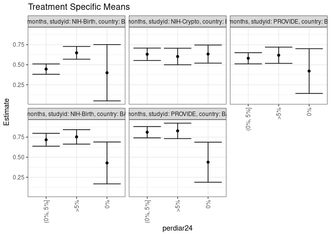

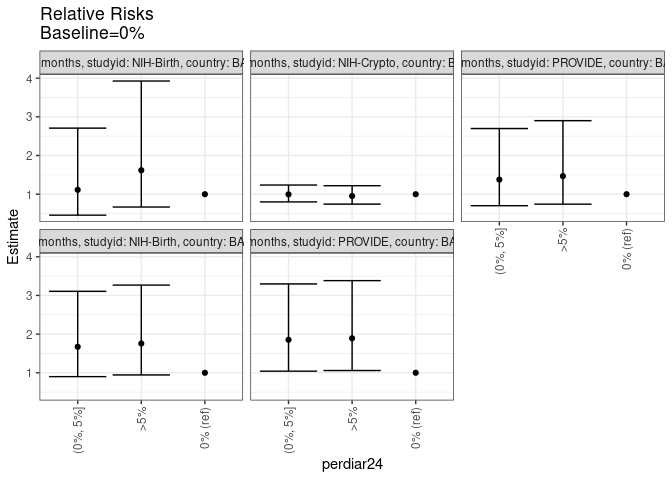

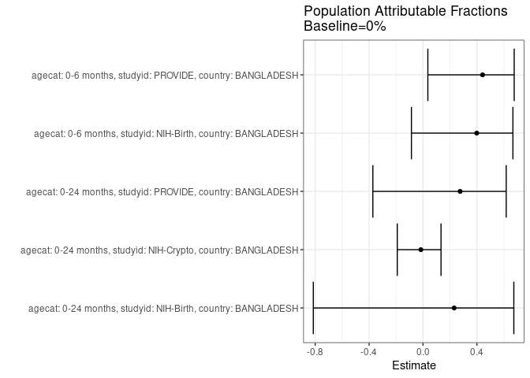

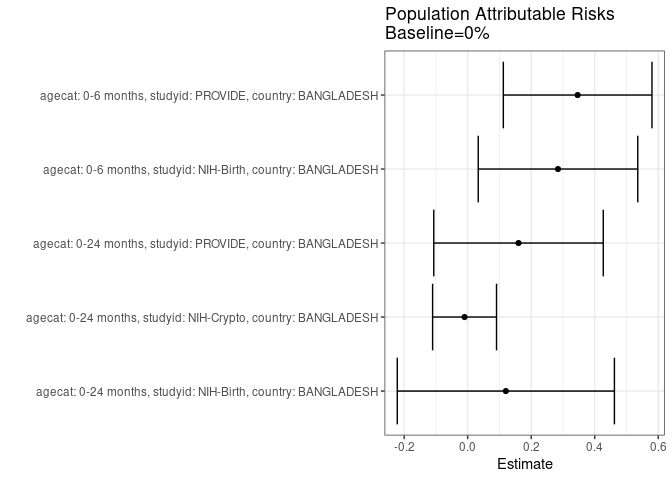

## Results Table

### Parameter: TSM

| agecat | studyid | country | intervention_level | baseline_level | estimate | ci_lower | ci_upper |
| --- | --- | --- | --- | --- | --- | --- | --- |
| 0-24 months | NIH-Birth | BANGLADESH | 0% | NA | 0.4000000 | 0.0491643 | 0.7508357 |
| 0-24 months | NIH-Birth | BANGLADESH | (0%, 5%] | NA | 0.4453441 | 0.3809000 | 0.5097883 |
| 0-24 months | NIH-Birth | BANGLADESH | >5% | NA | 0.6477987 | 0.5684298 | 0.7271677 |
| 0-24 months | NIH-Crypto | BANGLADESH | 0% | NA | 0.6323529 | 0.5194007 | 0.7453052 |
| 0-24 months | NIH-Crypto | BANGLADESH | (0%, 5%] | NA | 0.6298701 | 0.5524197 | 0.7073206 |
| 0-24 months | NIH-Crypto | BANGLADESH | >5% | NA | 0.6022727 | 0.4993932 | 0.7051522 |
| 0-24 months | PROVIDE | BANGLADESH | 0% | NA | 0.4210526 | 0.1425309 | 0.6995744 |
| 0-24 months | PROVIDE | BANGLADESH | (0%, 5%] | NA | 0.5800000 | 0.5109095 | 0.6490905 |
| 0-24 months | PROVIDE | BANGLADESH | >5% | NA | 0.6179775 | 0.5169387 | 0.7190164 |
| 0-6 months | NIH-Birth | BANGLADESH | 0% | NA | 0.4285714 | 0.1675904 | 0.6895524 |
| 0-6 months | NIH-Birth | BANGLADESH | (0%, 5%] | NA | 0.7166667 | 0.6364129 | 0.7969204 |
| 0-6 months | NIH-Birth | BANGLADESH | >5% | NA | 0.7528090 | 0.6625804 | 0.8430376 |
| 0-6 months | PROVIDE | BANGLADESH | 0% | NA | 0.4375000 | 0.1883651 | 0.6866349 |
| 0-6 months | PROVIDE | BANGLADESH | (0%, 5%] | NA | 0.8108108 | 0.7401781 | 0.8814435 |
| 0-6 months | PROVIDE | BANGLADESH | >5% | NA | 0.8275862 | 0.7316779 | 0.9234945 |

### Parameter: E(Y)

| agecat | studyid | country | intervention_level | baseline_level | estimate | ci_lower | ci_upper |
| --- | --- | --- | --- | --- | --- | --- | --- |
| 0-24 months | NIH-Birth | BANGLADESH | NA | NA | 0.5201900 | 0.4695846 | 0.5707955 |
| 0-24 months | NIH-Crypto | BANGLADESH | NA | NA | 0.6225806 | 0.5684562 | 0.6767051 |
| 0-24 months | PROVIDE | BANGLADESH | NA | NA | 0.5811688 | 0.5245443 | 0.6377934 |
| 0-6 months | NIH-Birth | BANGLADESH | NA | NA | 0.7130045 | 0.6535890 | 0.7724200 |
| 0-6 months | PROVIDE | BANGLADESH | NA | NA | 0.7837838 | 0.7252863 | 0.8422812 |

### Parameter: RR

| agecat | studyid | country | intervention_level | baseline_level | estimate | ci_lower | ci_upper |
| --- | --- | --- | --- | --- | --- | --- | --- |
| 0-24 months | NIH-Birth | BANGLADESH | 0% | 0% | 1.0000000 | 1.0000000 | 1.000000 |
| 0-24 months | NIH-Birth | BANGLADESH | (0%, 5%] | 0% | 1.1133603 | 0.4576898 | 2.708322 |
| 0-24 months | NIH-Birth | BANGLADESH | >5% | 0% | 1.6194969 | 0.6679847 | 3.926392 |
| 0-24 months | NIH-Crypto | BANGLADESH | 0% | 0% | 1.0000000 | 1.0000000 | 1.000000 |
| 0-24 months | NIH-Crypto | BANGLADESH | (0%, 5%] | 0% | 0.9960737 | 0.8016407 | 1.237665 |
| 0-24 months | NIH-Crypto | BANGLADESH | >5% | 0% | 0.9524313 | 0.7435086 | 1.220060 |
| 0-24 months | PROVIDE | BANGLADESH | 0% | 0% | 1.0000000 | 1.0000000 | 1.000000 |
| 0-24 months | PROVIDE | BANGLADESH | (0%, 5%] | 0% | 1.3775000 | 0.7033792 | 2.697700 |
| 0-24 months | PROVIDE | BANGLADESH | >5% | 0% | 1.4676966 | 0.7425231 | 2.901100 |
| 0-6 months | NIH-Birth | BANGLADESH | 0% | 0% | 1.0000000 | 1.0000000 | 1.000000 |
| 0-6 months | NIH-Birth | BANGLADESH | (0%, 5%] | 0% | 1.6722222 | 0.9003129 | 3.105951 |
| 0-6 months | NIH-Birth | BANGLADESH | >5% | 0% | 1.7565543 | 0.9443253 | 3.267394 |
| 0-6 months | PROVIDE | BANGLADESH | 0% | 0% | 1.0000000 | 1.0000000 | 1.000000 |
| 0-6 months | PROVIDE | BANGLADESH | (0%, 5%] | 0% | 1.8532819 | 1.0417293 | 3.297069 |
| 0-6 months | PROVIDE | BANGLADESH | >5% | 0% | 1.8916256 | 1.0579284 | 3.382315 |

### Parameter: PAR

| agecat | studyid | country | intervention_level | baseline_level | estimate | ci_lower | ci_upper |
| --- | --- | --- | --- | --- | --- | --- | --- |
| 0-24 months | NIH-Birth | BANGLADESH | 0% | NA | 0.1201900 | -0.2216808 | 0.4620609 |
| 0-24 months | NIH-Crypto | BANGLADESH | 0% | NA | -0.0097723 | -0.1103983 | 0.0908537 |
| 0-24 months | PROVIDE | BANGLADESH | 0% | NA | 0.1601162 | -0.1067355 | 0.4269679 |
| 0-6 months | NIH-Birth | BANGLADESH | 0% | NA | 0.2844331 | 0.0332574 | 0.5356087 |
| 0-6 months | PROVIDE | BANGLADESH | 0% | NA | 0.3462838 | 0.1122880 | 0.5802796 |

### Parameter: PAF

| agecat | studyid | country | intervention_level | baseline_level | estimate | ci_lower | ci_upper |
| --- | --- | --- | --- | --- | --- | --- | --- |
| 0-24 months | NIH-Birth | BANGLADESH | 0% | NA | 0.2310502 | -0.8139788 | 0.6740404 |
| 0-24 months | NIH-Crypto | BANGLADESH | 0% | NA | -0.0156964 | -0.1909441 | 0.1337635 |
| 0-24 months | PROVIDE | BANGLADESH | 0% | NA | 0.2755072 | -0.3722136 | 0.6174868 |
| 0-6 months | NIH-Birth | BANGLADESH | 0% | NA | 0.3989218 | -0.0858849 | 0.6672806 |
| 0-6 months | PROVIDE | BANGLADESH | 0% | NA | 0.4418103 | 0.0360080 | 0.6767860 |